# Quantitative Methods – Day 5: Difference-in-Difference Approaches

Harm H. Schuett

26 December, 2017

```r
library(ggplot2)
library(dplyr)
library(lfe)      # for FE models with instruments
```

# 1 Comparisons of within and between groups

Upon reflection, almost all causal strategies use comparisons across groups to identify causal effects. The whole idea of “treatment” is that one group gets “more” of the treatment than another and so on. As we have argued many times, that simple comparison is not ideal however. Treatment and control groups might differ for other reasons than the treatment and those reasons might affect the outcome as well. We can get a stronger comparison if we have an additional dimension to track treatment and outcomes. That dimension usually is time.

**Difference-in-difference** strategies typically try to exploit differences *within* groups over time as well as *between* groups. Here is why. Imagine an example from Gelman and Hill (2007), p. 228: The effect of a newly introduced school bus program on housing prices. Some neighborhoods are affected by the program and others are not. What is the problem by simply comparing neighborhoods receiving the program and others that don’t? They are likely confounders that affected which neighborhoods were included in the program and are also related to housing prices. We need to find ways to control for these confounders. If we have data on housing prices before and after the program’s start we can do better than comparing the two groups of neighborhoods. We can compare how they developed over time. A **difference-in-difference** approach calculates the difference in the before-after change between exposed and unexposed neighborhoods.

# 2 The common trend assumption

The **difference-in-difference** approach works if the (weaker) assumption of a common trend for both groups *in the absence of treatment* holds. In the example above this means that housing prices in exposed and unexposed neighborhoods would have developed similarly over time if the program would not have existed. This is weaker than assuming that neighborhoods are essentially comparable except for the treatment. With a diff-in-diff neighborhood groups can be different, but they should have developed similarly over time, if it weren’t for the treatment.

# 3 Diff-in-diff designs

## 3.1 Notation

The idea behind most diff-in-diff designs is a setup like this:

$$y_{i,g,t} = \alpha_g + \tau_t + \delta\times T_{i,g,t} + u_{i,g,t}$$

where $i$ is an individual observation, $g$ denotes the group it belongs to, and $t$ denotes the period of time of the observation. In this setup, the expected potential outcome for any group (treated or control) has the same form:

$$E[y^0_{i,g,t}] = \alpha_g + \tau_t$$
It allows for differences across groups $\alpha_g$ but assumes common time developments $\tau_t$ (you can think of these as time dummies).

## 3.2 Example

Let’s simulate the most basic form: Two groups (treated and control) and two periods (before and after)

```r
set.seed(666)
grp_size <- 50
data_1 <- data.frame(alpha = c(rep(4, grp_size*2), rep(12, grp_size*2)),
                     tau   = rep(c(rep(4, grp_size), rep(1, grp_size)), 2),
                     g     = c(rep(1, grp_size*2), rep(0, grp_size*2)),
                     after = rep(c(rep(0, grp_size), rep(1, grp_size)), 2)
                     )
data_1$delta <- with(data_1, ifelse(g == 1 & after == 1, 3, 0))
data_1$T <- with(data_1, ifelse(g == 1 & after == 1, 1, 0))
data_1$y <- with(data_1, alpha + tau + delta + rnorm(n=grp_size * 4, mean=0, sd=2))
```

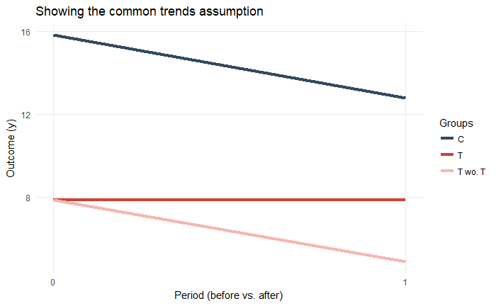

```r
data_2 <- data_1 %>%
  group_by(g, after) %>%
  summarize(y = mean(y)) %>%
  mutate(groups = if_else(g == 1, "T", "C"))
data_3 <- data_2 %>% filter(g == 1)
data_3[2, "y"] <- data_3[2, "y"] - 3
data_3$groups <- "T wo. T"
data_4 <- rbind(data_2, data_3)
ggplot(data_4) +
  geom_line(aes(x=after, y=y, color=groups), size=1.5) +
  scale_x_continuous(breaks=c(0,1)) +
  scale_color_manual(name="Groups", values=c("#34495E", "#CB4335", "#F5B7B1")) +
  theme_minimal() +
  theme(panel.grid.minor = element_blank()) +
  labs(title="Showing the common trends assumption",
       x="Period (before vs. after)",
       y="Outcome (y)")
```

You should take a look at that data and convince yourself that it fits our setup above. Afterwards, let’s look at regressions:

Treated versus all other obs

```r
summary(lm(y ~ T, data=data_1))
```

```
Call:
lm(formula = y ~ T, data = data_1)

Residuals:
    Min      1Q  Median      3Q     Max
-8.6002 -2.4728  0.2116  2.4697  8.9914

Coefficients:
            Estimate Std. Error t value Pr(>|t|)
(Intercept)  12.1664     0.2931  41.514  < 2e-16 ***
T            -4.3035     0.5861  -7.342 5.34e-12 ***
---
Signif. codes:  0 ‘***’ 0.001 ‘**’ 0.01 ‘*’ 0.05 ‘.’ 0.1 ‘ ’ 1

Residual standard error: 3.589 on 198 degrees of freedom
Multiple R-squared:  0.214, Adjusted R-squared:   0.21
F-statistic: 53.91 on 1 and 198 DF,  p-value: 5.335e-12
```

```
...
...
```

Difference between treated and control in after the treatment

```r
summary(lm(y ~ T, data=subset(data_1, after == 1)))
```

```
Call:
lm(formula = y ~ T, data = subset(data_1, after == 1))

Residuals:
   Min     1Q Median     3Q    Max
-5.749 -1.284 -0.015  1.574  4.608

Coefficients:
            Estimate Std. Error t value Pr(>|t|)
(Intercept)  12.7756     0.2954   43.25   <2e-16 ***
T            -4.9127     0.4177  -11.76   <2e-16 ***
---
Signif. codes:  0 ‘***’ 0.001 ‘**’ 0.01 ‘*’ 0.05 ‘.’ 0.1 ‘ ’ 1

Residual standard error: 2.089 on 98 degrees of freedom
Multiple R-squared:  0.5853,    Adjusted R-squared:  0.581
F-statistic: 138.3 on 1 and 98 DF,  p-value: < 2.2e-16
```

```
...
...
```

Difference before and after for treated group

```r
summary(lm(y ~ T, data=subset(data_1, g == 1)))
```

```
Call:
lm(formula = y ~ T, data = subset(data_1, g == 1))

Residuals:
    Min      1Q  Median      3Q     Max
-5.7493 -1.4104  0.0292  1.5060  4.4297

Coefficients:
             Estimate Std. Error t value Pr(>|t|)
(Intercept)  7.870395   0.292633  26.895   <2e-16 ***
T           -0.007463   0.413845  -0.018    0.986
---
Signif. codes:  0 ‘***’ 0.001 ‘**’ 0.01 ‘*’ 0.05 ‘.’ 0.1 ‘ ’ 1

Residual standard error: 2.069 on 98 degrees of freedom
Multiple R-squared:  3.318e-06, Adjusted R-squared:  -0.0102
F-statistic: 0.0003252 on 1 and 98 DF,  p-value: 0.9856
```

```
...
...
```

Difference-in-difference

```r
summary(lm(y ~ g*after, data=data_1))
```

```
Call:
lm(formula = y ~ g * after, data = data_1)

Residuals:
    Min      1Q  Median      3Q     Max
-6.1508 -1.4449 -0.0084  1.5780  5.3046

Coefficients:
            Estimate Std. Error t value Pr(>|t|)
(Intercept)  15.8532     0.3080  51.465  < 2e-16 ***
g            -7.9828     0.4356 -18.325  < 2e-16 ***
after        -3.0776     0.4356  -7.065 2.74e-11 ***
g:after       3.0701     0.6161   4.983 1.37e-06 ***
---
Signif. codes:  0 ‘***’ 0.001 ‘**’ 0.01 ‘*’ 0.05 ‘.’ 0.1 ‘ ’ 1

Residual standard error: 2.178 on 196 degrees of freedom
Multiple R-squared:  0.7135,    Adjusted R-squared:  0.7091
F-statistic: 162.7 on 3 and 196 DF,  p-value: < 2.2e-16
```

```
...
...
```

You should know enough by now about correlated omitted variable bias and confounders to explain these differences in regressions. Take a bit of time and write down your answers into the notebook below each regression

## 3.3 A more elabotate example

Often you see diff-in-diff implemented as a fixed-effects regression with the indicator variable:

```r
summary(felm(y ~ T | g + after | 0 | 0, data=data_1))
```

```
Call:
   felm(formula = y ~ T | g + after | 0 | 0, data = data_1)

Residuals:
    Min      1Q  Median      3Q     Max
-6.1508 -1.4449 -0.0084  1.5780  5.3046

Coefficients:
  Estimate Std. Error t value Pr(>|t|)
T   3.0701     0.6161   4.983 1.37e-06 ***
---
Signif. codes:  0 ‘***’ 0.001 ‘**’ 0.01 ‘*’ 0.05 ‘.’ 0.1 ‘ ’ 1

Residual standard error: 2.178 on 196 degrees of freedom
Multiple R-squared(full model): 0.7135   Adjusted R-squared: 0.7091
Multiple R-squared(proj model): 0.1125   Adjusted R-squared: 0.09887
F-statistic(full model):162.7 on 3 and 196 DF, p-value: < 2.2e-16
F-statistic(proj model): 24.83 on 1 and 196 DF, p-value: 1.369e-06
```

This is because group fixed effects take out the $\alpha_g$ components of the regression – you take out time-stable group differences. And time fixed effects take out the $\tau_t$, the common time effects. You are essentially left with:

$$y_{i,g,t} - \alpha_g - \tau_t = \delta\times T_{i,g,t} + u_{i,g,t}$$

The advantage of this regression approach to diff-in-diff is that we can easily add other covariates if we think it is necessary.

$$y_{i,g,t} = \alpha_g + \tau_t + \delta\times T_{i,g,t} + X_{i,g,t}\beta + u_{i,g,t}$$

and:

$$E[y^0_{i,g,t}] = \alpha_g + \tau_t + X_{i,g,t}\beta$$

And we can easily adopt more groups and periods if needed. For example, if we have neighborhoods, states or industries and some of these are treated while others are not, we can use neighborhood, state or industry fixed effects to take out the time-stable treatment/control-group differences.

Also, if we have a staggered adoption (some neighborhoods, states or industries get treated at different times) this is easily modeled as well.

## 3.4 Pitfalls in Diff-in-Diff

There are quite a few pitfalls when using this approach but most of them concern whether you have carefully thought about what the economic situation actually is. For example in job program evaluation studies, there is often a “dip”" in earnings or employment levels (actually called Ashenfelter’s dip (Ashenfelter and Card (1985)) in the periods leading up to treatment. This is because people who voluntarily join job programs often lost their jobs shortly before the treatment but people in the control did not. Such a pre-treatment dip in the treatment group would create a bias in our estimates. Always look out for such things.

# 4 Ecercises

1. Go to [Go to David Card’Site](http://davidcard.berkeley.edu/data_sets.html) and download the data for the famous Card and Krueger (1994) minimum wage study. Describe what the main hypothesis is, what the accompanying research design core assumptions are and replicate the main regression.

# 5 References

Card, David, and Alan B Krueger. 1994. “Minimum Wages and Employment: A Case Study of the Fast-Food Industry in New Jersey and Pennsylvania.” *The American Economic Review* 84 (4): 772–93.

Gelman, Andrew, and Jennifer Hill. 2007. *Data Analysis Using Regression and Multilevelhierarchical Models*. Cambridge University Press.